# Blood Cell Semantic Segmentation

From Mathematical Formulation in PyTorch to Low-Latency C++17 Edge Inference

BSc. Computer Science with Mathematics | AI & ML Systems Engineering Portfolio

2026

## Slide 1: End-to-End ML Systems Architecture

### Bridging Mathematical Rigor in PyTorch with Deterministic C++17 Edge Deployment

#### Python Research & Training (`src/python/`)

1. **Synchronized `transforms.v2` Pipeline** (`dataset.py`)
   - Bilinear image scaling ($I \in \mathbb{R}^{3 \times 416 \times 416}$) + Nearest-Neighbor mask projection ($Y \in \{0,1\}^{1 \times 416 \times 416}$).
2. **Custom U-Net Architecture** (`model.py`)
   - $31.04\text{M}$ parameters; supports unpadded (`padding=0`, $228\times 228$ output with `_center_crop` skip connections) & padded (`padding=1`, $416\times 416$) modes.
3. **Composite BCE + Soft Dice Optimization** (`train.py`, `evaluate.py`)
   - Log-sum-exp stabilized `BCEWithLogitsLoss` paired with continuous Frobenius Soft Dice relaxation.
4. **Constant-Folded ONNX Export** (`export_onnx.py`)
   - Fuses `BatchNorm2d` into `Conv2d` (`opset=17`), verified to $\mathbf{2.42 \times 10^{-6}}$ max logit error.

#### C++17 Production Inference (`src/cpp/`)

1. **OpenCV Ingestion & Preprocessing** (`inference_engine.cpp`)
   - Decodes `BGR` `uint8_t` $\to$ resizes $416\times 416$ $\to$ transposes `HWC` to contiguous planar `NCHW` `RGB` `float32` with ImageNet standardization.
2. **Zero-Copy ONNX Runtime Binding** (`Ort::Value`)
   - Binds `std::vector<float>::data()` directly into `Ort::MemoryInfo::CreateCpu` without intermediate heap copies.
3. **Monotonic Logit Thresholding** ($z > 0.0\text{f}$)
   - Bypasses $51,984$ `std::exp()` calls per frame via exact logit equivalence.
4. **Sub-Pixel Membrane Overlay** (`cv::findContours`)
   - Aligns the $228\times 228$ receptive field ($94\text{ px}$ crop) and renders anti-aliased cell contours.

## Slide 2: Clinical Problem & Dataset Formulation

### Formulating Blood Smear Segmentation as Dense Pixel-Wise Classification

#### Formal Mathematical Problem Definition

Given a digitized peripheral blood smear microscopy image $I \in \mathbb{R}^{H \times W \times 3}$, we seek a parameterized operator $f_\Theta$ mapping the continuous RGB lattice onto a discrete semantic mask lattice:

$$f_\Theta: \mathbb{R}^{H \times W \times 3} \longrightarrow \mathbb{R}^{H' \times W'} \xrightarrow{\;\sigma(\cdot)\;} [0, 1]^{H' \times W'} \xrightarrow{\;\mathbb{I}(\cdot > \tau)\;} \{0, 1\}^{H' \times W'}$$

*(Directly extensible to the $K$-class simplex $\Delta^{K-1}_{H' \times W'} \to \{0, 1, \dots, K-1\}^{H' \times W'}$ for Background, Erythrocytes/RBCs, Leukocytes/WBCs, and Platelets).*

#### Benchmark Dataset Structure ([BCCD with Mask](https://www.kaggle.com/datasets/jeetblahiri/bccd-dataset-with-mask))

- **Training Split (`data/train`)**: $1,169$ paired RGB smears (`.jpg`/`.png`) & binary masks (`.png`).
- **Validation / Test Split (`data/test`)**: $159$ held-out smear-mask pairs for unbiased generalization auditing.

**Key Hematological & Computer Vision Challenges**

1. **Severe Scale & Class Imbalance**:
   - Erythrocytes (RBCs) dominate foreground pixel area, leukocytes (WBCs) exhibit complex lobulated nuclear staining, and platelets occupy tiny fractional areas.
2. **Boundary Ambiguity & Rouleaux Formations**:
   - Touching or overlapping cells require crisp membrane localization rather than blurred regional blobs.
3. **Cross-Format Ground Truth Storage**:
   - Lossy JPEG compression on masks introduces ringing artifacts ($\notin \{0, 255\}$); our loader enforces stem-matched lossless `.png` resolution and strict binarization $(M > 0)$.

## Slide 3: Geometry of Synchronized Spatial Augmentations

### Preserving Topological Label Integrity Across Interpolation Spaces (`src/python/dataset.py`)

#### Synchronized Dihedral Group Action

Let $g_\theta \in D_2$ (horizontal reflection + spatial scaling) be sampled once per sample pair and applied jointly:
$$(I', Y') = \bigl(g_\theta(I),\; g_\theta(Y)\bigr), \quad \theta \sim \text{Bernoulli}(0.5)$$

#### Why Distinct Interpolation Kernels Are Mandatory

- **RGB Images ($I \in \mathbb{R}^{H \times W \times 3}$)**: Intensities reside in a continuous vector space; **Bilinear Interpolation** computes a valid convex combination of the $2 \times 2$ neighborhood:
  $$I'(x, y) = \sum_{i=0}^{1}\sum_{j=0}^{1} w_{ij}(x, y) \, I\bigl(\lfloor x \rfloor + i, \lfloor y \rfloor + j\bigr)$$
- **Semantic Masks ($Y \in \{0, \dots, K-1\}^{H \times W}$)**: Discrete nominal lattice with no metric ordering. Linearly interpolating between class $0$ and class $2$ synthesizes a false boundary of class $1$. **Nearest-Neighbor** projection preserves set membership:
  $$Y'(x, y) = Y\bigl(\operatorname{round}(x), \operatorname{round}(y)\bigr)$$

```python
# src/python/dataset.py (basedpyright strict-checked)
class VisionDataset(Dataset[tuple[torch.Tensor, torch.Tensor]]):
    @override
    def __getitem__(self, idx: int) -> tuple[torch.Tensor, torch.Tensor]:
        image_tensor = cast(torch.Tensor, F.to_image(image))
        mask_tensor = cast(torch.Tensor, F.to_image(mask))

        # 1. Geometry-aware spatial scaling to 416x416
        mask_tensor = F.resize(
            mask_tensor,
            [416, 416],
            interpolation=transforms.InterpolationMode.NEAREST,
        )
        image_tensor = F.resize(
            image_tensor,
            [416, 416],
            interpolation=transforms.InterpolationMode.BILINEAR,
        )

        # 2. Synchronized stochastic reflection g_theta
        if self.is_train and bool(torch.rand(1).item() < 0.5):
            image_tensor = F.hflip(image_tensor)
            mask_tensor = F.hflip(mask_tensor)

        # 3. Continuous [0,1] -> ImageNet Z-score vs. strict binary {0.0, 1.0}
        image_tensor = F.to_dtype(image_tensor, torch.float32, scale=True)
        image_tensor = cast(torch.Tensor, self.normalize(image_tensor))

        mask_tensor = F.to_dtype(mask_tensor, torch.float32, scale=False)
        mask_tensor = (mask_tensor > 0).float()
        return image_tensor, mask_tensor
```

## Slide 4: Feature Space Standardization & Hessian Conditioning

### Accelerating Gradient Convergence via Channel-Wise Affine Normalization

#### Channel-Wise Z-Score Standardization

Each RGB channel $c \in \{R, G, B\}$ is mapped from $[0, 1]$ to a zero-centered, unit-variance distribution:
$$\hat{I}_c = \frac{I_c - \mu_c}{\sigma_c}, \quad \begin{aligned}\mu &= [0.485,\; 0.456,\; 0.406] \\ \sigma &= [0.229,\; 0.224,\; 0.225]\end{aligned}$$

#### Optimization & Curvature Conditioning

- For the first convolutional layer $z = W * \hat{I}$, the Hessian of the loss with respect to weights $W$ satisfies $\mathbf{H}_W \propto \mathbb{E}[\hat{I}\hat{I}^\top]$.
- Unnormalized inputs ($I_c \in [0, 255]$ or $[0, 1]$ with positive mean) induce a large rank-1 eigenvalue spike, inflating the condition number:
  $$\kappa(\mathbf{H}_W) = \frac{\lambda_{\max}(\mathbf{H}_W)}{\lambda_{\min}(\mathbf{H}_W)} \gg 1$$
- Centering ($\mathbb{E}[\hat{I}_c] \approx 0$) and variance scaling ($\operatorname{Var}(\hat{I}_c) \approx 1$) pull $\kappa(\mathbf{H}_W)$ toward $1$, eliminating zig-zagging gradient trajectories and allowing AdamW ($\eta = 10^{-4}$) to converge rapidly within epochs.

#### Design Trade-Off: ImageNet vs. Giemsa Stain Statistics

| Normalization Strategy | Mathematical Advantage | Engineering Trade-Off |
| --- | --- | --- |
| **ImageNet Moments ($\mu_{\text{IN}}, \sigma_{\text{IN}}$)** | Preserves activation statistics for pre-trained ResNet/ConvNeXt encoders; universal cross-language standard | Slightly off-center for purple/pink Wright–Giemsa background plasma |
| **Dataset Giemsa Moments ($\mu_{\text{BCCD}}, \sigma_{\text{BCCD}}$)** | Exact $\mathbb{E}[\hat{I}_c] = 0$ on peripheral blood smears | Requires recomputing dataset-wide moments per lab scanner; breaks pre-trained weights |

**Critical Cross-Language Contract**

The exact constants $\mu, \sigma$ in `src/python/dataset.py` are mirrored as `constexpr std::array<float, 3>` in `src/cpp/include/inference_engine.hpp` so C++ inputs lie on the exact same manifold.

## Slide 5: Architectural Trade-Offs & Custom U-Net Topology

### Comparing Inductive Biases and Receptive Field Geometry (`src/python/model.py`)

| Architecture Family | Core Inductive Bias | Multi-Scale Mechanism | Boundary Precision vs. Compute Trade-Off |
| --- | --- | --- | --- |
| **U-Net (Our Custom Implementation)** | Translation equivariance + dense multi-scale skip connections | Symmetric 4-stage encoder-decoder concatenation (`31.04M` params) | Sharpest cell membrane localization; deterministic latency on CPU/edge |
| **DeepLabV3+** | Multi-scale context via dilated kernels | Atrous Spatial Pyramid Pooling (ASPP) | Captures global context without pooling loss; dilated gridding artifacts can miss tiny platelets |
| **SegFormer / ViT** | Global self-attention ($\mathcal{O}(N^2)$ token interaction) | Hierarchical patch merging + MLP decoder | Strong long-range semantics; weaker local edge prior and higher C++ runtime overhead |

#### Exact Spatial Recurrence in Our `UNet` (`padding=0` vs. `padding=1`)

- **DoubleConv Block**: Two $3\times 3$ convolutions (`bias=False` since `BatchNorm2d` affine shift $\beta_c$ absorbs any additive bias) + `BatchNorm2d` + `ReLU(inplace=True)`.
- **Unpadded Mode (`padding=0`, Ronneberger et al. 2015)**:
  - Each `DoubleConv` reduces height and width by $4\text{ px}$; across 4 encoder stages ($64 \to 128 \to 256 \to 512$), bottleneck ($1024$), and 4 decoder stages:
    $$H_{\text{in}} = 416 \longrightarrow H_{\text{bottleneck}} = 18 \longrightarrow H_{\text{out}} = 228$$
  - Eliminates zero-padding border hallucination; uses `_center_crop` on encoder skip tensors and a $94\text{ px}$ target border crop.

```python
# src/python/model.py: Copy-and-Crop Skip Alignment
@staticmethod
def _center_crop(
    encoder_tensor: torch.Tensor,
    target_height: int,
    target_width: int,
) -> torch.Tensor:
    _, _, h, w = encoder_tensor.shape
    diff_y: int = (h - target_height) // 2
    diff_x: int = (w - target_width) // 2
    return encoder_tensor[
        :, :, diff_y : diff_y + target_height, diff_x : diff_x + target_width
    ]

# Inside UNet.forward():
d4 = cast(torch.Tensor, self.up4(b))               # [B, 512, 36, 36]
e4_cropped = self._center_crop(e4, d4.shape[2], d4.shape[3])
d4 = torch.cat([e4_cropped, d4], dim=1)            # [B, 1024, 36, 36]
d4 = cast(torch.Tensor, self.dec4(d4))             # [B, 512, 32, 32]
```

## Slide 6: Loss Landscape Design (`BCEDiceLoss`)

### Combining Log-Sum-Exp Pixel Cross-Entropy with Differentiable Frobenius Dice Relaxation

#### 1. Logit-Stabilized Binary Cross-Entropy ($\mathcal{L}_{\text{BCE}}$)

Treating each pixel $i \in \{1, \dots, N\}$ ($N = 228^2 = 51,984$) as an independent Bernoulli trial with raw logit $z_i \in \mathbb{R}$ and probability $p_i = \sigma(z_i)$:
$$\mathcal{L}_{\text{BCE}}(z, y) = \frac{1}{N} \sum_{i=1}^{N} \Bigl[ \max(z_i, 0) - z_i y_i + \ln\bigl(1 + e^{-|z_i|}\bigr) \Bigr]$$
- **Strength**: Smooth, strictly convex gradient $\frac{\partial \mathcal{L}_{\text{BCE}}}{\partial z_i} = \frac{1}{N}(p_i - y_i)$. - **Limitation**: Weights all pixels equally, allowing majority background regions to dominate minor cell classes.

#### 2. Continuous Soft Dice Relaxation ($\mathcal{L}_{\text{Dice}}$)

Using the Frobenius inner product $\langle p, y \rangle_F = \sum_{i=1}^N p_i y_i$ and $L_1$ norms:
$$\mathcal{L}_{\text{Dice}}(p, y) = 1 - \frac{2 \langle p, y \rangle_F + \epsilon}{\|p\|_1 + \|y\|_1 + \epsilon}, \quad \epsilon = 10^{-6}$$
- **Composite Objective** ($\alpha = 0.5$):
$$\mathcal{L}_{\text{total}}(z, y) = 0.5 \, \mathcal{L}_{\text{BCE}}(z, y) + 0.5 \, \mathcal{L}_{\text{Dice}}\bigl(\sigma(z), y\bigr)$$

```python
# src/python/evaluate.py
@final
class BCEDiceLoss(nn.Module):
    def __init__(self, bce_weight: float = 0.5, smooth: float = 1e-6) -> None:
        super().__init__()
        self.bce_weight = bce_weight
        self.smooth = smooth
        self.bce_loss = nn.BCEWithLogitsLoss()

    @override
    def forward(self, logits: torch.Tensor, targets: torch.Tensor) -> torch.Tensor:
        targets_aligned = align_target_mask(logits, targets)

        # 1. Numerically stable Log-Sum-Exp BCE on raw logits
        bce = cast(torch.Tensor, self.bce_loss(logits, targets_aligned))

        # 2. Differentiable Soft Dice on continuous probabilities
        probs = torch.sigmoid(logits)
        probs_flat = probs.contiguous().view(probs.shape[0], -1)
        targets_flat = targets_aligned.contiguous().view(probs.shape[0], -1)

        intersection = (probs_flat * targets_flat).sum(dim=1)
        cardinality = probs_flat.sum(dim=1) + targets_flat.sum(dim=1)

        soft_dice = (2.0 * intersection + self.smooth) / (cardinality + self.smooth)
        return self.bce_weight * bce + (1.0 - self.bce_weight) * (1.0 - soft_dice.mean())
```

## Slide 7: Set-Theoretic Validation Metrics

### Evaluating Spatial Overlap via Sørensen–Dice ($F_1$) and Jaccard Index (IoU)

#### Discrete Set-Theoretic Definitions

Given binarized prediction set $P = \{i : \sigma(z_i) > 0.5\}$ and ground-truth set $G = \{i : y_i = 1\}$:

$$\text{IoU}(P, G) = J = \frac{|P \cap G|}{|P \cup G|} = \frac{\text{TP}}{\text{TP} + \text{FP} + \text{FN}}$$

$$\text{Dice}(P, G) = D = \frac{2|P \cap G|}{|P| + |G|} = \frac{2\text{TP}}{2\text{TP} + \text{FP} + \text{FN}}$$

#### Functional Bijection & Inequality

On any single sample, $J$ and $D$ are linked by a strict homeomorphism on $[0, 1]$:
$$J = \frac{D}{2 - D} \Longleftrightarrow D = \frac{2J}{1 + J}, \qquad J \le D \;\;\forall D \in [0, 1]$$

#### Why Track Both Across the Test Dataset?

Because $g(D) = \frac{D}{2 - D}$ is **strictly convex** on $[0, 1)$ ($g''(D) = \frac{4}{(2-D)^3} > 0$), Jensen’s Inequality implies that dataset averages diverge when variance is present across images:

- **Mean Dice ($\mathbb{E}[D]$)**: Reflects average harmonic boundary agreement ($F_1$ score).
- **Mean IoU ($\mathbb{E}[J]$)**: Penalizes worst-case single-image boundary failures much more severely than Mean Dice—essential for clinical quality assurance.

**Empirical Consistency Check on `data/test` ($159$ smears):** Theoretical single-sample transform of $\bar{D} = 0.9655$ gives $\frac{0.9655}{2 - 0.9655} = 0.9333$; our actual dataset mean IoU is **$\bar{J} = 0.9344$**, confirming tight, low-variance performance across the entire test cohort.

## Slide 8: Graph Compilation & Constant Folding (`export_onnx.py`)

### Bridging Dynamic PyTorch Eager Execution to Static ONNX Runtime

#### Algebraic Conv2d + BatchNorm2d Fusion

Calling `model.eval()` freezes running batch statistics $(\hat{\mu}_c, \hat{\sigma}_c^2)$. During `torch.onnx.export(..., do_constant_folding=True, opset_version=17)`, each `BatchNorm2d` layer is algebraically absorbed into the preceding $3 \times 3$ `Conv2d` weights $W_c$ and bias $\tilde{b}_c$:

$$y_c = \gamma_c \frac{(W_c * x) - \hat{\mu}_c}{\sqrt{\hat{\sigma}_c^2 + \epsilon}} + \beta_c \;\equiv\; \tilde{W}_c * x + \tilde{b}_c$$

where the folded parameters are pre-computed at export time:
$$\tilde{W}_c = \frac{\gamma_c}{\sqrt{\hat{\sigma}_c^2 + \epsilon}} W_c, \qquad \tilde{b}_c = -\frac{\gamma_c \hat{\mu}_c}{\sqrt{\hat{\sigma}_c^2 + \epsilon}} + \beta_c$$

- **Runtime Impact**: Eliminates **18 separate BatchNorm tensor passes** per inference frame in C++.

```python
# src/python/export_onnx.py
model = UNet(in_channels=3, out_channels=1, padding=0).to(device)
model.load_state_dict(torch.load(weights_path, weights_only=True))
model.eval()  # Freezes BatchNorm stats for constant folding

dummy_input = torch.randn(1, 3, 416, 416, dtype=torch.float32)
torch.onnx.export(
    model, (dummy_input,), str(output_path),
    export_params=True, opset_version=17,
    do_constant_folding=True,
    input_names=["input"], output_names=["logits"],
)

# Numerical Parity Audit: PyTorch Eager vs. ONNX Runtime
ort_session = ort.InferenceSession(str(output_path), providers=["CPUExecutionProvider"])
ort_logits = np.asarray(ort_session.run(["logits"], {"input": dummy_input.numpy()})[0])
max_abs_diff = float(np.max(np.abs(pytorch_out.numpy() - ort_logits)))
# Verified Output:
# Numerical parity verified! Max absolute difference: 2.42e-06
```

**Verified Graph Parity (`outputs/model.onnx`)**:
$$\max_{i \in \{1, \dots, 51984\}} \bigl|z_{\text{PyTorch}}^{(i)} - z_{\text{ONNX}}^{(i)}\bigr| = \mathbf{2.42 \times 10^{-6}} < 10^{-5}$$

## Slide 9: Low-Latency C++17 Inference Engine (`src/cpp/`)

### Memory Layout Transposition, Zero-Copy Binding & Monotonic Logit Thresholding

#### 1. Fused Single-Pass FMA Planar Normalization

- Precomputes scale $\frac{1}{255\sigma}$ and bias $-\frac{\mu}{\sigma}$ to replace divisions with fused multiply-adds (FMA).
- Writes directly from continuous interleaved `BGR` bytes into contiguous planar slices ($H \cdot W = 173,056$), eliminating intermediate `cv::Mat` heap allocations.

#### 2. Persistent `Ort::IoBinding` Pre-allocation

- Binds persistent `Ort::Value` in CPU arena memory once to eliminate per-inference allocation overhead.

#### 3. Monotonic Logit Thresholding + SIMD Vectorization

- Since $\sigma(z) > \tau \iff z > \ln(\frac{\tau}{1 - \tau})$, $\tau = 0.5 \implies z > 0.0\text{f}$.
- Thresholds raw logits directly via `cv::compare(..., CMP_GT)` using hardware SIMD vector instructions.

```cpp
// src/cpp/src/inference_engine.cpp
// 1. Fused single-pass BGR uint8 -> planar NCHW + ImageNet FMA
const uint8_t* src = resized_bgr.ptr<uint8_t>(0);
for (int i = 0; i < hw; ++i) {
    b_plane[i] = static_cast<float>(src[i * 3 + 0]) * b_scale + b_bias;
    g_plane[i] = static_cast<float>(src[i * 3 + 1]) * g_scale + g_bias;
    r_plane[i] = static_cast<float>(src[i * 3 + 2]) * r_scale + r_bias;
}

// 2. Persistent Ort::IoBinding & zero-allocation execution
io_binding_->BindInput(input_name_.c_str(), input_tensor_);
io_binding_->BindOutput(output_name_.c_str(), memory_info_);
session_->Run(run_options_, *io_binding_);

// 3. Monotonic logit threshold (z > 0.0f) via SIMD cv::compare
const cv::Mat logits_mat(out_h, out_w, CV_32FC1, const_cast<float*>(logits));
cv::compare(logits_mat, logit_threshold, out_binary_mask, cv::CMP_GT);
cv::findContours(out_binary_mask, contours, cv::RETR_EXTERNAL, cv::CHAIN_APPROX_SIMPLE);
cv::drawContours(out_contour_overlay, contours, -1, cv::Scalar(0, 0, 255), 2, cv::LINE_AA);
```

## Slide 10: Empirical Results, Visual Verification & Error Analysis

#### Training & Held-Out Test Benchmark (`159` Smears)

| Stage / Split | Combined Loss $\downarrow$ | Mean Dice ($F_1$) $\uparrow$ | Mean IoU ($J$) $\uparrow$ | Pixel Acc $\uparrow$ |
| --- | --- | --- | --- | --- |
| **Epoch 01 (Val)** | `0.2081` | `0.9118` | `0.8604` | — |
| **Epoch 02 (Val)** | `0.1262` | `0.9475` | `0.9050` | `0.9660` |
| **Final Test (`data/test`)** | **`0.0644`** | **`0.9655`** | **`0.9344`** | **`0.9766`** |

#### Failure Mode & Edge-Case Analysis

1. **Touching Erythrocytes (Rouleaux Bridges)**:
   - Binary semantic segmentation merges adjacent cell membranes separated by $< 2\text{ px}$ into a single connected component in `cv::findContours`.
2. **Unpadded Receptive Field Margin ($94\text{ px}$)**:
   - With `padding=0`, cells near the outer $94\text{ px}$ frame border are excluded from the $228\times 228$ output; solved via reflection tiling or `padding=1`.

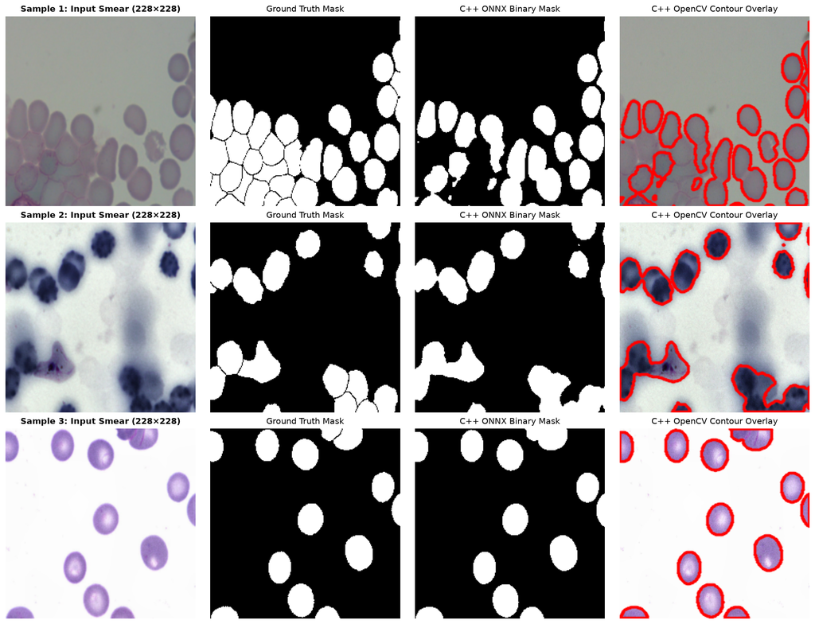

C++17 ONNX Runtime Inference Verification: Input Smear ($228\times 228$), Ground Truth Mask, C++ Binary Mask ($z > 0.0\text{f}$), and OpenCV Membrane Contours (`cv::drawContours`)

## Slide 11: Engineering Takeaways & Production Roadmap

### Scaling From Research Prototype to Clinical Hematology Production

#### Core Systems & Mathematical Takeaways

1. **End-to-End Type & Memory Safety**:
   - Strict static typing in Python (`basedpyright` + `ruff`) paired with RAII-managed `-Wall -Wextra -Wpedantic` C++17 (`std::unique_ptr<Ort::Session>`) prevents silent tensor shape or pointer bugs.
2. **Mathematical Shortcut $\implies$ Systems Speedup**:
   - Folding `BatchNorm2d` into `Conv2d` during ONNX export and exploiting sigmoid monotonicity ($z > 0.0\text{f}$) reduce runtime compute without sacrificing a single bit of classification accuracy.
3. **Standalone Deployment Portability**:
   - The compiled `./inference_app` binary runs natively on Linux clinical workstations without a Python interpreter or GIL contention.

#### Concrete Next Steps for Clinical Deployment

1. **Topological Instance Separation (Watershed)**:
   - Compute the Euclidean Distance Transform $\text{EDT}(P)$ on predicted binary masks to locate local maxima as cell centroids, then apply Marker-Controlled Watershed to split touching RBCs.
2. **Macenko Optical Density Stain Normalization**:
   - Transform RGB intensities to Optical Density space ($\text{OD} = -\log_{10}(I / I_0)$) and apply SVD stain-vector decomposition to normalize Wright–Giemsa variations across hospital scanners.
3. **Hardware Execution Providers & Quantization**:
   - Enable `OrtTensorRTProviderOptions` (FP16) or post-training **INT8 calibration** ($4\times$ weight compression) for embedded point-of-care hematology analyzers.

## Backup Slide A1: Exact Soft Dice Gradient Derivation (Q&A)

### Quotient-Rule Derivation of $\frac{\partial \mathcal{L}_{\text{Dice}}}{\partial z_k}$ for Backpropagation Analysis

Let $p_i = \sigma(z_i) \in (0, 1)$ and $y_i \in \{0, 1\}$. Define the intersection $I(p) = \sum_{i=1}^N p_i y_i$ and cardinality sum $U(p) = \sum_{i=1}^N p_i + \sum_{i=1}^N y_i$, so that:

$$\mathcal{L}_{\text{Dice}}(p, y) = 1 - \frac{2 I(p) + \epsilon}{U(p) + \epsilon}$$

Differentiating with respect to a single pixel’s predicted probability $p_k$ ($\text{where } \frac{\partial I}{\partial p_k} = y_k \text{ and } \frac{\partial U}{\partial p_k} = 1$):

$$\frac{\partial \mathcal{L}_{\text{Dice}}}{\partial p_k} = -\frac{2 y_k \bigl(U(p) + \epsilon\bigr) - 1 \cdot \bigl(2 I(p) + \epsilon\bigr)}{\bigl(U(p) + \epsilon\bigr)^2} = \frac{2 I(p) + \epsilon - 2 y_k \bigl(U(p) + \epsilon\bigr)}{\bigl(\|p\|_1 + \|y\|_1 + \epsilon\bigr)^2}$$

Applying the chain rule through the logistic sigmoid derivative $\frac{\partial p_k}{\partial z_k} = p_k(1 - p_k)$:

$$\frac{\partial \mathcal{L}_{\text{Dice}}}{\partial z_k} = \left[\frac{2 \langle p, y \rangle_F + \epsilon - 2 y_k \bigl(\|p\|_1 + \|y\|_1 + \epsilon\bigr)}{\bigl(\|p\|_1 + \|y\|_1 + \epsilon\bigr)^2}\right] p_k (1 - p_k)$$

- **Why Combining with $\mathcal{L}_{\text{BCE}}$ Stabilizes Training**: When foreground area $\|y\|_1$ is small, the denominator $(\|p\|_1 + \|y\|_1 + \epsilon)^2$ can cause high gradient variance; adding $\frac{\partial \mathcal{L}_{\text{BCE}}}{\partial z_k} = \frac{1}{N}(p_k - y_k)$ anchors pixel-wise descent directions even when $p_k \to 0$ or $1$.

## Backup Slide A2: Runtime Benchmarking Methodology (Q&A)

### Rigorous Protocol: C++17 ONNX Runtime vs. Python `torch.compile()`

| Benchmark Dimension | Python Eager (`nn.Module`) | Python `torch.compile(mode="max-autotune")` | C++17 `bcsd::SegmentationEngine` (ONNX Runtime) |
| --- | --- | --- | --- |
| **Graph Optimizations** | None (per-op dispatcher overhead) | TorchInductor operator fusion + Triton kernels | Static constant folding + `ORT_ENABLE_ALL` graph fusion |
| **Cold-Start / Warmup** | Fast ($\sim 0.2\text{ s}$) | Slow ($\sim 15\text{–}40\text{ s}$ JIT compilation on first batch) | Instantaneous ($\sim 30\text{ ms}$ session load) |
| **Memory Footprint (`RSS`)** | $\sim 1.2\text{–}2.5\text{ GB}$ (Python + PyTorch runtime) | $\sim 1.8\text{–}3.0\text{ GB}$ (compiler caches + CUDA context) | **$< 150\text{ MB}$** (standalone native binary) |
| **Latency Tail ($p_{99}$)** | Subject to Python GC & GIL jitter | Low on GPU ($B > 1$), higher dispatch overhead on CPU ($B=1$) | **Deterministic low $p_{99}$ variance** for real-time $B=1$ streams |

#### Key Benchmarking Rules Used in Evaluation

1. **Isolate Forward Pass ($T_{\text{infer}}$) vs. End-to-End ($T_{\text{e2e}}$)**: Time `session_->Run()` separately from `cv::imread`/`preprocess`/`postprocess`.
2. **Mandatory Warm-Up ($W = 20$ iterations)**: Exclude initial memory arena allocation and JIT autotuning from steady-state percentiles ($p_{50}, p_{90}, p_{99}$).
3. **Device Synchronization**: Call `torch.cuda.synchronize()` before and after `time.perf_counter()` when benchmarking GPU execution providers.